# Approaches to biomedical knowledge

Session #1: Ontologies: OBO, RDF, RDFS, and OWL

Peter N Robinson

## contents

- Bio-Ontologies
- OBO: Open Bio-Ontologies
- RDF
- RDFS
- The Web Ontology Language (OWL)

## Bio-Ontologies

In this part of the course we will review ontologies and algorithms and we will present the Human Phenotype Ontology (HPO), which has been developed by our group since 2007.

- You will not need a book for this course
- But if you would like to learn more:

> **Introduction to Bio-Ontologies** > (Chapman & Hall/CRC Mathematical & Computational Biology)  
> Peter N. Robinson and Sebastian Bauer  
> 2011

[figure not shown]

## Bio-Ontologies

**Game plan**

- Introduction to ontologies: OBO, RDF, RDFS, and OWL (today)
- Gene Ontology and Overrepresentation Analysis (lecture #2)
- Model-based Gene Set Analysis (lecture #3)
- Human Phenotype Ontology (HPO), semantic similarity, and Phenomizer (lecture #4)

## What is an Ontology?

**Philosophy**

[figure not shown]

**$\rightarrow$**

**Artificial Intelligence**

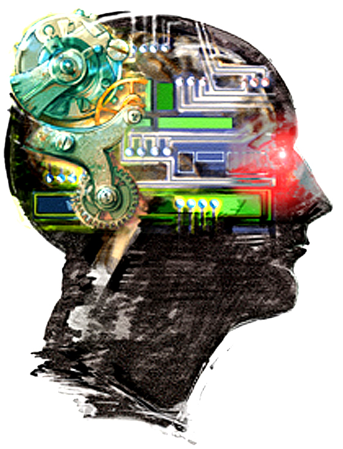

**$\rightarrow$**

**Biomedical Research**

[figure not shown]

## What is an Ontology?

*“An ontology is a specification of a conceptualization.”*

**Tom Gruber, 1993**

Ontologies are on the right of a scale of increasing semantic complexity:

[figure not shown]

- As we move from left to right, we move from simple **lists of terms** (Catalog/Glossary) to **hierarchical relationships** (Thesaurus/Subclassing) and finally to **formal logic** (Restrictions/Constraints).

## OBO: Open Bio-Ontologies

- Open Bio-Ontology (OBO)
- The OBO Foundry is a collective of ontology developers committed to collaboration and adherence to shared principles.
- Develop a family of interoperable ontologies that are both logically well-formed and scientifically accurate.
- Open use, collaborative development, non-overlapping content, and common syntax based on models like the Gene Ontology (GO).

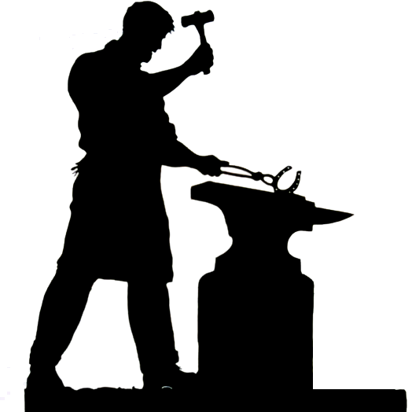

http://www.obofoundry.org/

## OBO Format

Gene Ontology and OBO foundry members have developed a simple ontology language called OBO.

- Models a subset of the semantics available in OWL 2.
- Human-readable flat file format.
- Most current software also supports JSON, but we will stick with OBO for a moment to introduce the basics!
- Begins with a header:

```
format-version: 1.2
date: 29:07:2010 12:36
auto-generated-by: OBO-Edit 2.0
subsetdef: goslim_candida "Candida GO slim"
subsetdef: goslim_generic "Generic GO slim"
default-namespace: gene_ontology
```

## OBO Stanzas

OBO stanzas can refer to universal types [Term], type definitions [Typedef], or instances [Instances].

```
[Term]
id: GO:0000031
name: mannosylphosphate transferase activity
namespace: molecular_function
def: "Catalysis of the transfer of a mannosylphosphate group from one compound to another." [GOC:jl]
is_a: GO:0016740 ! transferase activity
```

## OBO Stanzas (Identifiers)

The stanza begins with the id, which is a unique identifier comparable to an accession number.

```
id: GO:0000031
name: mannosylphosphate transferase activity
namespace: molecular_function
def: "Catalysis of the transfer of a mannosylphosphate group from one compound to another." [GOC:jl]
is_a: GO:0016740 ! transferase activity
```

Each term also has a name (concise human-readable description):

```
id: GO:0000031
name: mannosylphosphate transferase activity
namespace: molecular_function
def: "Catalysis of the transfer of a mannosylphosphate group from one compound to another." [GOC:jl]
is_a: GO:0016740 ! transferase activity
```

All other tag:value items are optional.

## OBO Stanzas (Semantic Links)

The `is_a` keyword indicates subclass links.

Example: mannosylphosphate transferase activity is a subclass of GO:0016740.

```xml
id: GO:0000031
name: mannosylphosphate transferase activity
namespace: molecular_function
def: "Catalysis of the transfer of a mannosylphosphate group from one compound to another." [GOC:jl]
is_a: GO:0016740 ! transferase activity
```

Note: Text following an ! is a comment.

## OBO subclass and other relations

Terms may have any number of is_a relations.

For all other relations, the keyword relationship (or specific relation type) is used.

The relation type name must be defined in a [Typedef] stanza.

```xml
[Typedef]
id: part_of
name: part_of
xref: OBO_REL:part_of
is_transitive: true
```

- **transitive**: If A part_of B and B part_of C, then A part_of C.

## RDF / RDFS

OWL and the Semantic Web

OWL was developed by the W3C to enable richer integration and interoperability of data on the Web.

- Part of the Semantic Web effort.
- Designed to connect websites at the level of data rather than presentation (HTML).
- Enables computational inference.

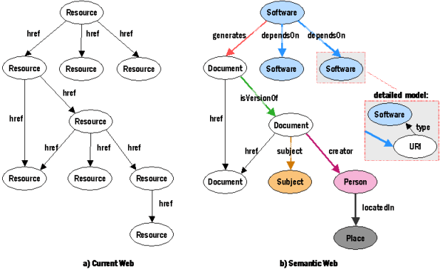

image: [W3C Semantic Web Activity](https://www.w3.org/2001/12/semweb-fin/w3csw)

## Resource Description Framework (RDF)

OWL is built upon RDF and RDFS.

- RDF expresses propositions using formal vocabularies.
- Basic building block: The Triple (Subject, Predicate, Object).

```
# Example of an RDF Triple
http://www.example.org/ :hasCreator "John Smith" .
```

- subject: `http://www.example.org/`
- predicate: `hasCreator`
- object: `John Smith`

## RDF: Serialization (XML)

RDF is an abstract model, but often serialized as RDF/XML.

```xml
<rdf:RDF xmlns="http://purl.uniprot.org/core/"
         xmlns:rdf="http://www.w3.org/1999/02/22-rdf-syntax-ns#">

  <rdf:Description rdf:about="http://purl.uniprot.org/enzyme/1.14.11.2">
    <rdf:type rdf:resource="http://purl.uniprot.org/core/Enzyme"/>
    <name>Procollagen-proline dioxygenase</name>
    <activity>L-proline-[procollagen] + 2-oxoglutarate + O(2) = ...</activity>
    <cofactor>Iron</cofactor>
  </rdf:Description>
</rdf:RDF>
```

## RDF: Namespaces

A **namespace** indicates which vocabulary a name belongs to.

- `xmlns="…"` declares the **default namespace**: it applies to every element name *without* a prefix
- `xmlns:rdf="…"` declares the **prefix** `rdf`: it applies to names written `rdf:…`
- A full URI is formed by concatenating **namespace + local name**

| Written in the file | Namespace | Full URI |
| --- | --- | --- |
| `name` | default | `http://purl.uniprot.org/core/name` |
| `activity` | default | `http://purl.uniprot.org/core/activity` |
| `cofactor` | default | `http://purl.uniprot.org/core/cofactor` |
| `rdf:type` | `rdf` | `http://www.w3.org/1999/02/22-rdf-syntax-ns#type` |

**Note**

A namespace URI is just an **identifier**; it is simply prepended to the local name. It does not have to point to a web page, and the concatenation is plain string appending, which is why namespaces end in `/` or `#`.

## RDF

RDF is designed to make computer-processable statements in the context of the Semantic Web.

- Requires a system of machine-processable identifiers for identifying resources that are **unique** across the entire Web.
- Requires a computer language for representing and processing these statements.
- The existing Web architecture provides **URLs** (Uniform Resource Locators) as one form of identifier.
  - Example: For `http://www.example.org`, the **location** is `www.example.org` and the **protocol** is `http`.

## RDF: URLs, URIs, and URNs

URLs are one of two specific classes of **Uniform Resource Identifier (URI)**.

- The other class is the **Uniform Resource Name (URN)**.
- A URN represents a name for a resource that is unique and global throughout the Web.
- **Example:** `urn:isbn:0691141339` (ISBN for a specific book).
- **n.b.:** While this URI is unique, it cannot be used to retrieve the book from the Web directly.

## RDF: Serialization

RDF is an abstract data model. The process of representing it as a computer file is called **serialization**.

- RDF files are frequently written in **RDF/XML**.

## RDF: Serialization

- The following example is modified from an RDF file created by the Uniprot consortium.

```xml
1. <?xml version='1.0' encoding='UTF-8'?>
2. <rdf:RDF xmlns="http://purl.uniprot.org/core/"
3.          xmlns:rdf="http://www.w3.org/1999/02/22-rdf-syntax-ns#"
4. >
5.
6.   <rdf:Description
7.        rdf:about="http://purl.uniprot.org/enzyme/1.14.11.2">
8.     <rdf:type rdf:resource="http://purl.uniprot.org/core/Enzyme"/>
9.     <name>Procollagen-proline dioxygenase</name>
10.    <name>Procollagen-proline 4-dioxygenase</name>
11.    <name>Prolyl 4-hydroxylase</name>
12.    <activity>L-proline-[procollagen] + 2-oxoglutarate + O(2)
13.              = trans-4-hydroxy-L-proline-[procollagen] +
14.                succinate + CO(2).
15.    </activity>
16.    <cofactor>Iron</cofactor>
17.    <cofactor>L-ascorbic acid</cofactor>
18.   </rdf:Description>
19. </rdf:RDF>
```

- Line 1: The XML declaration,
- Line 2: Opens an element, which indicates that the XML content from line 2 up to the closing tag at line 19 represents RDF.
- Line 2: The default name space for this file is `http://purl.uniprot.org/core/`
- Line 3: The namespace declaration (`xmlns`) states that the prefix is equivalent to the namespace URI , and allows the prefix to be used in place of the complete URL in the remainder of the RDF file.
- Lines 6-18: Contain the specific information of the RDF file.

## RDF: rdf:about

```xml
<?xml version='1.0' encoding='UTF-8'?>
<rdf:RDF xmlns="http://purl.uniprot.org/core/"
         xmlns:rdf="http://www.w3.org/1999/02/22-rdf-syntax-ns#">

  <rdf:Description
       rdf:about="http://purl.uniprot.org/enzyme/1.14.11.2">
    <rdf:type rdf:resource="http://purl.uniprot.org/core/Enzyme"/>
    <name>Procollagen-proline dioxygenase</name>
    <name>Procollagen-proline 4-dioxygenase</name>
    <name>Prolyl 4-hydroxylase</name>
    <activity>L-proline-[procollagen] + 2-oxoglutarate + O(2)
              = trans-4-hydroxy-L-proline-[procollagen] +
              succinate + CO(2).
    </activity>
    <cofactor>Iron</cofactor>
    <cofactor>L-ascorbic acid</cofactor>
  </rdf:Description>
</rdf:RDF>
```

- RDF statements are descriptions of resources
- **rdf:about** is a fundamental attribute used to identify the **Subject** of a description.
- Line 6: Indicates that the *subject* of the RDF statements contained within the `Description` element is http://purl.uniprot.org/enzyme/1.14.11.2.
- We will abbreviate the subject as `:1.14.11.2` in the following slides

## RDF: rdf:type

```xml
<?xml version='1.0' encoding='UTF-8'?>
<rdf:RDF xmlns="http://purl.uniprot.org/core/"
         xmlns:rdf="http://www.w3.org/1999/02/22-rdf-syntax-ns#">

  <rdf:Description
       rdf:about="http://purl.uniprot.org/enzyme/1.14.11.2">
    <rdf:type rdf:resource="http://purl.uniprot.org/core/Enzyme"/>
    <name>Procollagen-proline dioxygenase</name>
    <name>Procollagen-proline 4-dioxygenase</name>
    <name>Prolyl 4-hydroxylase</name>
    <activity>L-proline-[procollagen] + 2-oxoglutarate + O(2)
              = trans-4-hydroxy-L-proline-[procollagen] +
              succinate + CO(2).
    </activity>
    <cofactor>Iron</cofactor>
    <cofactor>L-ascorbic acid</cofactor>
  </rdf:Description>
</rdf:RDF>
```

## RDF: structural metadata (what something is) vs descriptive data (what something is called or does).

```xml
<?xml version='1.0' encoding='UTF-8'?>
<rdf:RDF xmlns="http://purl.uniprot.org/core/"
         xmlns:rdf="http://www.w3.org/1999/02/22-rdf-syntax-ns#">

  <rdf:Description
       rdf:about="http://purl.uniprot.org/enzyme/1.14.11.2">
    <rdf:type rdf:resource="http://purl.uniprot.org/core/Enzyme"/>
    <name>Procollagen-proline dioxygenase</name>
    <name>Procollagen-proline 4-dioxygenase</name>
    <name>Prolyl 4-hydroxylase</name>
    <activity>L-proline-[procollagen] + 2-oxoglutarate + O(2)
              = trans-4-hydroxy-L-proline-[procollagen] +
              succinate + CO(2).
    </activity>
    <cofactor>Iron</cofactor>
    <cofactor>L-ascorbic acid</cofactor>
  </rdf:Description>
</rdf:RDF>
```

## RDF: Serialization

**RDF triples for procollagen-proline dioxygenase**.

| Subject | Predicate | Object |
| --- | --- | --- |
| `:1.14.11.2` | `rdf:type` | `:Enzyme` |
| `:1.14.11.2` | `:name` | Procollagen-proline dioxygenase |
| `:1.14.11.2` | `:name` | Procollagen-proline 4-dioxygenase |
| `:1.14.11.2` | `:name` | Prolyl 4-hydroxylase |
| `:1.14.11.2` | `:activity` | L-proline-[procollagen] + 2-oxoglutarate + O(2) = trans-4-hydroxy-L-proline-[procollagen] + succinate + CO(2). |
| `:1.14.11.2` | `:cofactor` | Iron |
| `:1.14.11.2` | `:cofactor` | L-ascorbic acid |

Each of the predicates indicates a different property of the enzyme 1.14.11.2. The triples with the predicate `:name` should be read as “:1.14.11.2 has the name Procollagen-proline dioxygenase” etc., and the triples with the predicate `:cofactor` should be read as “:1.14.11.2 has the cofactor Iron” etc.

## RDF: Model

RDF models statements as nodes and edges in a graph. For any given triple, there is a node for the subject, a node for the object, and an edge for the predicate, which is directed from the subject node to the object node.

For instance, the triple `:1.14.11.2 rdf:type :Enzyme` can be represented as shown here:

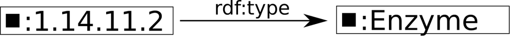

Figure 1: **Graphical Representation of an RDF Triple**. The subject, `:1.14.11.2`, and the object, `:Enzyme`, are shown as nodes, while the predicate is shown as an edge leading from the subject to the object.

# RDF: Model

This entire collection of RDF statements correspond to a labeled directed graph.

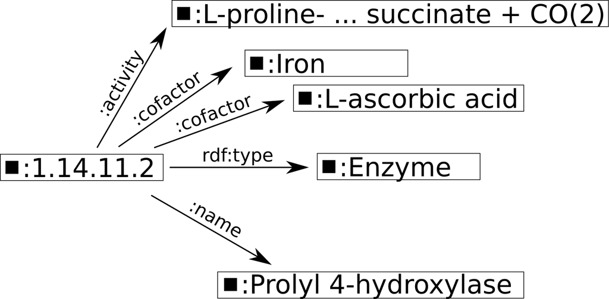

## RDF: Where are literals (strings) allowed?

- Suppose we want to represent something that does not have a URI.

| Component | Allowed Types |
| --- | --- |
| Subject | IRI (Internationalized Resource Identifier) or Blank Node |
| Predicate | IRI only |
| Object | IRI, Blank Node, or Literal (such as a string, integer, or date) |

- RDF is designed to model a graph of interconnected resources identified by global identifiers (IRIs).
- Because a literal string has no global identity or web address, it cannot be the starting point (subject) of a relationship.
- Literals are strictly endpoints (objects) meant to represent values like names, numbers, or text descriptions.

IRI (RFC 3987) is a newer standard designed to expand upon URIs by allowing Unicode characters rather than just US-ASCII.

## RDF: bnodes

RDF provides several syntactic constructs for expressing more complex statements that go beyond what can be expressed by the simple subject/predicate/object form of the triples presented up to now.

- Suppose we want to represent something that does not have a URI.
- This can be done using an RDF construct called a *blank node* (*bnode* for short).
- Let us say we want to express the statement *Someone called Douglas wrote a book entitled “Hitchhiker’s Guide to the Galaxy.”
- Clearly, it is impossible to provide a URI for the concept *Someone called Douglas*.
- Instead, we use a bnode to express the statement about this “someone.”

```
[ :firstname "Douglas"]
```

## RDF: bnodes (Continued)

The statement in the previous slide means $X$, such that there exists some $X$ (i.e., somebody) such that $X$ has a first name Douglas.

- It is convention to leave a space after the opening square bracket as if to indicate the presence of the “blank” subject of these triples.
- We can now use this statement as an `rdf:subject`.

```
[ :firstname "Douglas"] dc:wrote [ dc:title "Hitchhiker's Guide to the Galaxy"] .
```

## RDF: reification

Let’s say we then do a search in our favorite Web search engine and find a Wikipedia article saying that Douglas Adams wrote a book entitled “Hitchhiker’s Guide to the Galaxy.” Furthermore, let’s say we are skeptical about this statement and want to use RDF to express the fact that Wikipedia *claims* that Douglas Adams wrote a book entitled “Hitchhiker’s Guide to the Galaxy.”

RDF represents a reified statement as four statements using RDF properties and objects: the triplet (S, P, O), reified by resource R, is represented by:

- `R` `rdf:type` `rdf:Statement`
- `R` `rdf:subject` `S`
- `R` `rdf:predicate` `P`
- `R` `rdf:object` `O`

Essentially, RDF “reifies” (makes) a triple into a “thing” about which other RDF statements can be made. The triple is assigned an identifier and treated as a resource.

## RDF: reification (Example)

Assuming that the appropriate qname prefixes have been defined, we can express our statement about Wikipedia’s claim as follows:

```
@prefix rdf: http://www.w3.org/1999/02/22-rdf-syntax-ns# .

_:x rdf:type rdf:Statement .
_:x rdf:subject :"Douglas Adams" .
_:x rdf:predicate :wrote .
_:x rdf:object :"Hitchhiker's Guide to the Galaxy" .

web:wikipedia q:says _:x
```

## RDFS

A schema is a formal definition of the syntax of a language, and a schema language is a language for expressing that definition. In SQL, the schema is the structure of the database that defines the objects in the database.

- RDF Schema (RDFS) is intended as a framework for interpreting the meaning of data expressed in RDF.
- RDFS provides additional specifications and keywords that allow many kinds of *inference* to be performed.

RDFS is essentially just a pre-defined set of RDF resources.

| Category | Terms |
| --- | --- |
| **Terms for classes** | `rdfs:Class` `rdfs:subClassOf` |
| **Terms for properties** | `rdfs:domain` `rdfs:range` `rdfs:subPropertyOf` |
| **Special classes** | `rdfs:Resource` `rdfs:Literal` `rdfs:Datatype` |
| **Terms for collections** | `rdfs:member` `rdfs:Container` `rdfs:ContainerMembershipProperty` |
| **Special properties** | `rdfs:comment`, `rdfs:seeAlso` `rdfs:isDefinedBy`,`rdfs:label` |

## RDFS: *is a* ain’t always *is a*

Probably the most important concept for inference in RDFS is that of the class. Classes provide an abstraction mechanism for grouping resources with similar characteristics.

It is important to distinguish between two different usages of the phrase “is a” in the English language:

- **Mickey is a mouse**: This means a particular individual called *Mickey* is an **instance of** the class Mouse.
- **A mouse is a rodent**: This means the class “mouse” **is a subclass of** the class “rodent,” implying that every being that is a mouse is also a rodent.

As we shall see, RDFS has a different syntax for expressing each relation.

## RDFS: is a

Imagine we have defined an ontology and have provided definitions at `http://www.my-example.org`, which we assign to the qname prefix `x`.

- It is already possible in RDF to express the statement *Mickey is a mouse*:

```
x:Mickey rdf:type x:Mouse .
```

## RDFS: is a (Subclasses)

However, there is no mechanism built into RDF with which we could express the statement that *mouse* is a subclass of *rodent*.

- The RDFS keywords `rdfs:Class` and `rdfs:subClassOf` can be used for this purpose.
- We first declare that `x:Mouse` and `x:Rodent` are RDFS classes, and then state that `x:Mouse` is a subclass of `x:Rodent`.

```
@prefix x: http://www.my-example.org .

x:Mouse rdf:type rdfs:Class .
x:Rodent rdf:type rdfs:Class .
x:Mouse rdfs:subClassOf x:Rodent .
```

## RDFS: is a (Inference Rule 1)

One of the RDFS inference rules states that if there are asserted triples of the form:

```
X rdfs:subClassOf Y .
b rdf:type X .
```

then the following triple can be inferred:

```
b rdf:type Y .
```

## RDFS: is a (Inference Rule 2)

Another inference rule states that the subclass relation is **transitive**.

That is, if there are asserted triples about classes $X$, $Y$, and $Z$:

```
X rdfs:subClassOf Y .
Y rdfs:subClassOf Z .
```

then the following triple can be inferred:

```
X rdfs:subClassOf Z .
```

## RDFS: is a (Transitivity Example)

- if we assert the following triples:

```
x:Mouse rdf:type rdfs:Class .
x:Rodent rdf:type rdfs:Class .
x:Mammal rdf:type rdfs:Class .

x:Mouse rdfs:subClassOf x:Rodent .
x:Rodent rdfs:subClassOf x:Mammal .
```

then we can infer that mice are mammals:

```
x:Mouse rdfs:subClassOf x:Mammal .
```

## RDFS: Properties and Inference

Similar inference rules apply to properties. For instance, we can define a simple hierarchy of biochemical regulation with the following RDF statements:

```
@prefix r: http://www.regulation.org .

r:regulates rdf:type rdfs:Property .
r:positively_regulates rdf:type rdfs:Property .
r:negatively_regulates rdf:type rdfs:Property .

r:positively_regulates rdfs:subPropertyOf r:regulates .
r:negatively_regulates rdfs:subPropertyOf r:regulates .
```

If proteins A and B have been defined in a namespace pro, we can state that A positively regulates B by asserting the following triple:

```
pro:A  r:positively_regulates pro:B .
```

## RDFS: Properties and Inference

There is an inference rule for RDFS properties stating that if the following triples are asserted:

```
P rdfs:subPropertyOf Q .
X P Y .
```

Then the following triple can be inferred:

```
X Q Y .
```

Example: Using our regulation hierarchy, from the fact that Protein A *positively regulates* protein B, we can infer that Protein A regulates Protein B:

```
pro:A  r:regulates pro:B .
```

**Tip**

Similarly to the situation with classes, the subproperty relation is transitive.

## RDFS: Property Domains

RDFS provides a syntax for specifying the range and domain of properties. Recall that the *domain* of a function is the set of values for which a function is defined. The *range* is the set of all values the function takes for the values in the domain.

- RDFS’ use of domain and range enables inference.
- The statement `P rdfs:domain D` means that the subject of any triple using predicate `P` must be an instance of class `D`.

If the following two triples are asserted:

```
P rdfs:domain D .
X P Y .
```

then the following triple is inferred:

```
X rdf:type D .
```

## RDFS: Property Ranges

Similarly, the RDFS statement `P rdfs:range R` for an `rdf:Property P` and an `rdf:Class R` means that the resource denoted by the **object** of a triple whose predicate is `P` is an instance of the class `R`.

If the following two triples are asserted:

```
P rdfs:range R .
X P Y .
```

Then the following triple can be inferred:

```
Y rdf:type R .
```

## RDFS: Property Domains and Ranges (Example)

The following highly simplified example was adapted from the National Cancer Institute (NCI) thesaurus.

```
:drug_affects_protein rdf:type rdfs:Property .
:Drug rdf:type rdfs:Class .
:Protein rdf:type rdfs:Class .

:drug_affects_protein rdfs:domain :Drug .
:drug_affects_protein rdfs:range :Protein .
```

If we now additionally assert the following triple:

```
:Nilotinib  :drug_affects_protein :BCR-ABL .
```

Then we can infer the following two triples:

```
:Nilotinib rdf:type :Drug .
:BCR-ABL rdf:type :Protein .
```

In fact, Nilotinib is a selective Bcr-Abl tyrosine kinase inhibitor that is used in the treatment of chronic myeloid leukemia.

## RDFS: Property Domains and Ranges (Graph)

The figure below displays the graph corresponding to these triples. The inferred triples are shown using dashed lines.

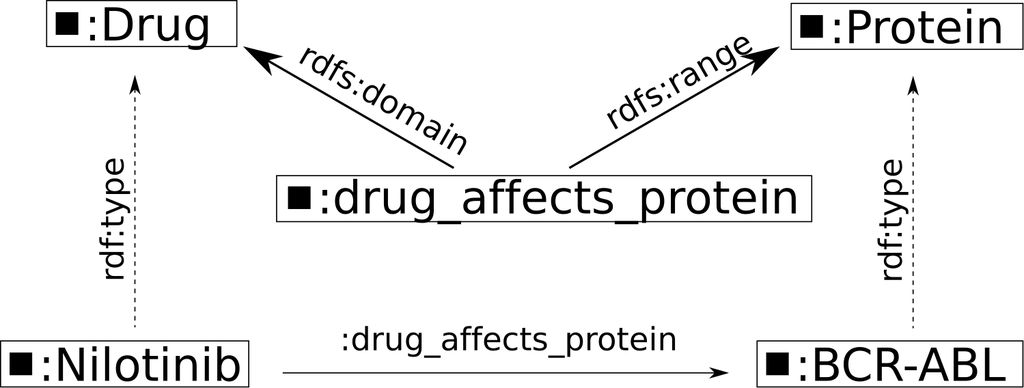

Figure 3: **Example of RDFS Inference in an RDF Graph**. Because of the domain and range restrictions on the predicate `:drug_affects_protein`, it can be inferred that `:Nilotinib` is a drug and `:BCR-ABL` is a protein.

## RDFS: Intersections and Unions

Yet other forms of inference in RDFS resemble to a certain extent conclusions about set intersections and set unions.

- If $Z$ is a subclass of both class $X$ and class $Y$, and $b$ is defined as an instance of $Z$, then $b$ can be inferred to be an instance of both $X$ and $Y$.

If the following triples are asserted:

```
Z rdfs:subClassOf X .
Z rdfs:subClassOf Y .
b rdf:type Z .
```

Then these two triples can be inferred:

```
b rdf:type X .
b rdf:type Y .
```

## RDFS: Intersections and Unions (Continued)

For instance, if we state that:

```
:Pig rdfs:subClassOf :Mammal .
:Pig rdfs:subClassOf :FarmAnimal .
```

Then we can conclude that a particular pig is both a mammal and a farm animal. The class :Pig can be considered to occupy the intersection between those two classes.On the other hand, asserting that:

```
:Cow rdfs:subClassOf :Mammal .
:Cow rdfs:subClassOf :FarmAnimal .
```

Does not imply that a cow is a pig!

**Limits of RDFS**

RDFS constructs are not designed to express an exact mathematical equality between sets, such as $A = B \cap C$. It only expresses “is a” relationships, not “is only and exactly” relationships.

## RDFS: Intersections and Unions (Union)

It is also possible to express something similar to set union in RDFS.

If we assert the following triples:

```
X rdfs:subClassOf Z .
Y rdfs:subClassOf Z .
```

Then, if either of the two following statements are asserted

```
b rdf:type X .
b rdf:type Y .
```

…then, it can be inferred that:

```
b rdf:type Z .
```

# RDFS: Intersections and Unions

- For instance, if we assert the triples

```
:HairBearingAnimal rdfs:subClassOf :Mammal .
:AnimalWithMammaryGlands rdfs:subClassOf :Mammal .
```

- then we can infer that any animal with hair and mammary glands is a mammal.

## The Web Ontology Language (OWL)

The acronym OWL stands for **W**eb **O**ntology **L**anguage. While the most natural acronym would have been “WOL,” **OWL** was chosen because it is easier to pronounce.<sup>1</sup>

In essence, OWL is an ontology language that builds upon RDF and RDFS but provides more powerful inference rules and built-in constructs.

- OWL can be understood as an extension of RDFS that allows more powerful inference to be performed.
- To a first approximation, we can say that OWL extends the inference capabilities already present in RDFS by the addition of new constructs and new rules.

[figure not shown]

[^1]: The claim that the choice of the acronym OWL had something to do with the character Owl from *Winnie the Pooh*, who spelled his name WOL, is apocryphal.

## Defining Classes in OWL

An important aspect of OWL is its ability to define classes with considerably more expressivity than RDFS.

OWL classes can be defined in two primary ways:

- **Enumerated Collections:** Classes representing a specific, closed collection of individuals (e.g., *Paul*, *John*, and *Mary*).
- **Conceptual Definitions:** Classes representing concepts that can have an indeterminate number of instances (e.g., *Mitochondrion*).

## Defining Classes in OWL

OWL provides six different mechanisms for defining classes:

1. **Named Classes**: Indicated by a URI.
2. **Enumerations**: A list of all specific individuals in the class.
3. **Property Restrictions**: Defining a class by how its members relate to other things.
4. **Intersection**: The overlap of two or more class descriptions.
5. **Union**: The combination of two or more class descriptions.
6. **Complement**: Everything that does *not* belong to a specific class.

Aside from the first type, each of these mechanisms defines classes by placing **restrictions** on the things that belong to the class.

## Classes in OWL: Enumeration

Perhaps the easiest to understand is the enumeration type, which essentially just provides a list of all individuals that belong to the class.

For instance, the following class definition expressed using **RDF/XML** syntax creates a class containing exactly the four Beatles:

```xml
<owl:Class>
  <owl:oneOf rdf:parseType="Collection">
    <owl:Thing rdf:about="#John"/>
    <owl:Thing rdf:about="#Paul"/>
    <owl:Thing rdf:about="#George"/>
    <owl:Thing rdf:about="#Ringo"/>
  </owl:oneOf>
</owl:Class>
```

[figure not shown]

## Classes in OWL: Property Restriction

An *A-Microtubule* can be defined as “A complete cylindrical microtubule that is part of a microtubule doublet in cilia.”

```xml
<owl:Class rdf:about="#A-Microtubule">
  <rdfs:label>A-Microtubule</rdfs:label>
  <rdfs:subClassOf rdf:resource="#Cilium Microtubule"/>

  <rdfs:subClassOf>
    <owl:Restriction>
      <owl:onProperty rdf:resource="#isPhysicalPartOf"/>
      <owl:someValuesFrom rdf:resource="#Cytoskeleton"/>
    </owl:Restriction>
  </rdfs:subClassOf>

  <rdfs:subClassOf>
    <owl:Restriction>
      <owl:onProperty rdf:resource="#isPhysicalPartOf"/>
      <owl:someValuesFrom rdf:resource="#Cilium"/>
    </owl:Restriction>
  </rdfs:subClassOf>
</owl:Class>
```

- In `rdf:about="#A-Microtubule"`, the hashmark (`#`) acts as a fragment identifier (anchor) in a URI/IRI.
- `#A-Microtubule` is a local name
- a specific resource defined within the current document or namespace rather than a completely external file or web page.
- The full unique IRI is obtained by combining the base URI (not shown here, but could be `http://example.org/ontology#`) and the local name
- The full IRI is then `http://example.org/ontology#A-Microtubule`

## Classes in OWL: Property Restriction (Logic)

A property restriction is a special kind of class description that describes an **anonymous class**—specifically, the class of all individuals that satisfy the restriction.

- The previous RDF/XML code states that the class *A-Microtubule* is a subclass of an anonymous class defined by being a physical part of some *cytoskeleton*.
- It is also a subclass of another anonymous class defined by being a physical part of some *cilium*.

> **In plain English:** Every A-microtubule is part of a cilium and simultaneously part of a cytoskeleton.

## Classes in OWL: Property Restriction (Value Constraints)

OWL distinguishes two kinds of property restrictions: **Value Constraints** and **Cardinality Constraints**. A value restriction $V$ on some property $P$ has the following general form:

```xml
<rdfs:subClassOf>
  <owl:Restriction>
    <owl:onProperty rdf:resource="P" />
    <owl:allValuesFrom rdf:resource="#V"/>
  </owl:Restriction>
</rdfs:subClassOf>
```

`owl:allValuesFrom` states that for each instance of the class being described, **every** value for $P$ must fulfill the constraint.

- **Confusing Caveat:** `owl:allValuesFrom` does **not** necessarily mean that an instance of the class *must* have the property $P$. It merely states that **if** an instance does have $P$, then the value must be from class $V$.
- **The Universal Quantifier:** This is analogous to the logic of $\forall$ in predicate calculus.
- **Formal Logic:** Recall that the formula $(\forall x) P(x)$ essentially means “for all $x$, if $x$ exists in this context, then it must satisfy $P$.”<sup>1</sup>
[^2]: According to this logic it is true that “All Martians are green” (because there are no Martians!)

## Classes in OWL: Negation

Classes can be defined by stating what they are **not**.

- For instance, the Ontology for Biomedical Investigations (OBI) describes a class of cells that **do not express** the CD8 receptor using the `owl:complementOf` keyword.
- This is achieved by defining the intersection of the class “Cell” and the **complement** of the class of things that “have part CD8 receptor.”

```xml
<owl:intersectionOf rdf:parseType="Collection">
  <owl:Class rdf:about="CL:cell"/>

  <owl:Class>
    <owl:complementOf>
      <owl:Restriction>
        <owl:onProperty>
          <owl:TransitiveProperty rdf:about="#has_part"/>
        </owl:onProperty>
        <owl:someValuesFrom>
          <owl:Class rdf:about="#CD8 receptor"/>
        </owl:someValuesFrom>
      </owl:Restriction>
    </owl:complementOf>
  </owl:Class>
</owl:intersectionOf>
```

## Classes in OWL: Negation (The Pitfalls)

**The “Kitchen Sink” Problem**

Unexpected results can be obtained from the naive use of `owl:complementOf`.

- **The Logic:** While one might be tempted to think that the complement of *Man* is *Woman*, the formal meaning of `owl:complementOf` *Man* is **everything in the universe that is not a Man**.
  - This includes the kitchen sink, the planet Neptune, and the Pacific Ocean.
- **The Solution:** `owl:complementOf` is almost always combined with other restrictions (intersections) to narrow the scope.

> **Example:** To define *Woman*, you would use the **Intersection** of *Human Being* and the **Complement** of *Man*.

## Classes in OWL: Union

OWL provides a union operator that is analogous to the set union operator: $A \cup B$.

- For instance, we can define the class **Human** as the union of the classes **Man** and **Woman**:

```xml
<owl:Class rdf:ID="Human">
  <owl:unionOf rdf:parseType="Collection">
    <owl:Class rdf:about="#Man" />
    <owl:Class rdf:about="#Woman" />
  </owl:unionOf>
</owl:Class>
```

## Classes in OWL: Union (the wrong way to define it)

Contrast the `owl:unionOf` construct to the following **incorrect** attempt to define *Human* as a subclass of *Man* and *Woman*:

```xml
<owl:Class rdf:ID="Human">
  <rdfs:subClassOf rdf:resource="#Man" />
  <rdfs:subClassOf rdf:resource="#Woman" />
</owl:Class>
```

Why this fails:

- The “And” vs. “Or” Logic: By using rdfs:subClassOf twice, you are stating that every Human must be a Man AND simultaneously a Woman.
- Unsatisfiability: If Man and Woman are defined as disjoint (meaning they cannot overlap), this class becomes unsatisfiable.
- The Empty Set: An unsatisfiable class is one that cannot contain any possible individuals.

In formal logic, this is equivalent to the empty set ($\emptyset$).

**Important**

The formula $A = \{ C \cap \neg C \}$ is unsatisfiable because it implies a direct contradiction.

## Individuals in OWL

In OWL, `rdf:type` is the property that connects an individual to a class of which it is a member.

If we have a class of cities:

```xml
<owl:Class rdf:ID="City"/>
```

We can declare individual cities to be members of this class. The following two syntactical forms have identical meanings:

- **Option 1**: Direct Class Tag

This uses the class name as the XML element tag.

```xml
<City rdf:ID="Berlin"/>
```

- **Option 2**: Explicit Typing

This uses owl:Thing (the root class of everything) and explicitly states the type.

```xml
<owl:Thing rdf:about="#Berlin">
  <rdf:type rdf:resource="#City"/>
</owl:Thing>
```

## What is the logic here?

[figure not shown]

## OWL: Conclusion and Next Steps

- **The Tip of the Iceberg:** We have barely scratched the surface of OWL’s logical capabilities in this lecture.
- **Hands-on Learning:** You will create your own ontology in the upcoming **Exercise**, where you will have the chance to explore these constructs (and more) in a practical setting.
- **Official Resources:** The [W3C Website](https://www.w3.org/OWL/) provides comprehensive documentation and technical specifications for the OWL family of languages.

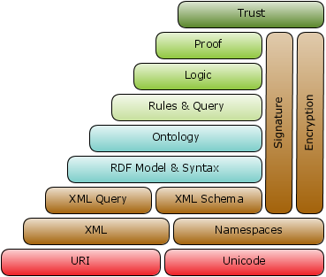

Semantic Web Layer Cake

## Homework

HOMEWORK You will create an Indian food ontology and infer whether certain dishes are vegetarian or non-veg.

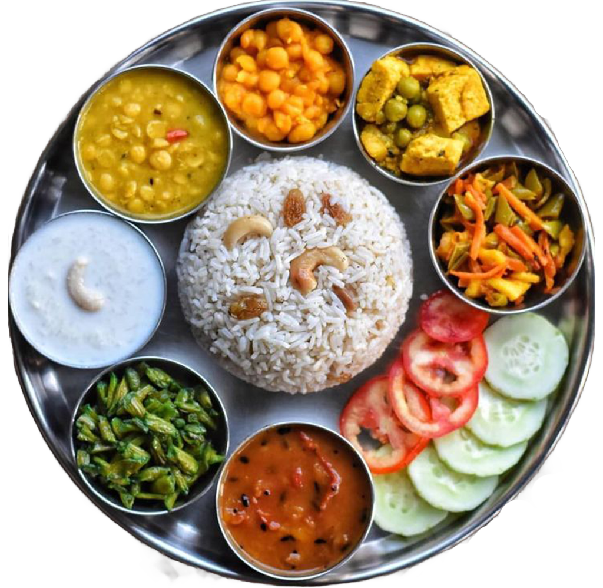

## Further Reading

- [Foundations of Semantic Web Technologies](https://www.semantic-web-book.org) (Excellent book)
- [Introduction to Bio-Ontologies](https://www.routledge.com/Introduction-to-Bio-Ontologies/Robinson-Bauer/p/book/9780367659271)
- [W3C W3C Web Ontology Language documentation](https://www.w3.org/OWL/)
- [OWL2 technical documentation](https://www.w3.org/TR/2012/REC-owl2-overview-20121211/)